# Data Mining Project

Lutz Daniel Leonardo Invernizzio

2016 M12 27

## Data Mining 1- Final Project

# First Part - Data Importation and clean-up

We start first with importing important packages and the file. Unknown data are marked as “-” therefore we need to add this information in the read_excel command

```r
library(readxl)
library(dplyr)
library(ggplot2)
library(lubridate)
library(DMwR)
library(rpart.plot)
library(e1071)
library(nnet)
library(earth)
policeData <- read_excel("crime.xls", sheet=1, col_names = TRUE, col_types = NULL, na = "-")
```

Now we can start the clean-up. Important for us is the format of the data. Therefore we are going to check, how our data are formated:

```r
sapply(policeData, class)
```

```
## $Date
## [1] "POSIXct" "POSIXt"
##
## $Hour
## [1] "character"
##
## $`Offense Type`
## [1] "character"
##
## $Beat
## [1] "character"
##
## $Premise
## [1] "character"
##
## $BlockRange
## [1] "character"
##
## $StreetName
## [1] "character"
##
## $Type
## [1] "character"
##
## $Suffix
## [1] "character"
##
## $`# offenses`
## [1] "numeric"
```

We see, that we have to change the format of Date and Hour.

```r
policeData$Date<-ymd(policeData$Date)
policeData$Hour<-as.numeric(policeData$Hour)
```

To make it easier for us handling the data, we have to remove characters like white space from the first line

```r
names(policeData) <-gsub("'", "", names(policeData), fixed=TRUE)
names(policeData) <-gsub("#", "n", names(policeData), fixed=TRUE)
names(policeData) <-gsub(" ", "_", names(policeData), fixed=TRUE)
```

Important part of the cleaning is analysing the represented values.

```r
table(policeData$Offense_Type)
```

```
##
##           1.000000 Aggravated Assault         Auto Theft
##                  1                641               1131
##           Burglary             Murder               Rape
##               1886                 23                 62
##            Robbery              Theft
##                838               5670
```

Obviously “1.000000” is not an offense type, and we are going to replace it with “NA”

```r
policeData$Offense_Type[policeData$Offense_Type=="1.000000"]<-NA
```

For our work, we need some more information:

- Dividing the day into the three shifts
- adding the information of the day,week day, month and year

```r
policeData<-mutate(policeData,wday=wday(Date, label=TRUE), day=day(Date),
                   month=month(Date,label=TRUE), year=year(Date))
shift1<-policeData[policeData$Hour>=8&policeData$Hour<12,]
shift2<-policeData[policeData$Hour>=12&policeData$Hour<19,]
shift3<-rbind(policeData[policeData$Hour>19,],policeData[policeData$Hour<8,])
```

# Second Part: Data Explore Analysis

We start to get an overview of the information we have to analyse the data regardingn:

- how many informations are given
- how many informations about each shift are given
- from which years do we have information
- which months are represented

How many events are reported:

```r
nrow(policeData)
```

```
## [1] 10252
```

How many are reported for shift 1 , shift 2 and shift 3 respectively

```r
nrow(shift1)
```

```
## [1] 2242
```

```r
nrow(shift2)
```

```
## [1] 4241
```

```r
nrow(shift3)
```

```
## [1] 3266
```

We have informations from the years:

```r
table(policeData$year)
```

```
##
## 1915 1980 2000 2005 2006 2007 2008 2010 2012 2013 2014 2015
##    3    1    1    1    1    1    2    2    6   10  398 9826
```

and months:

```
##
##  Jan  Feb  Mar  Apr  May  Jun  Jul  Aug  Sep  Oct  Nov  Dec
## 9846    4    0    0    9    8    5   10   16   10   43  301
```

Obviously our main information are coming from january and the year 2015. This is important for the third task, since we don’t know how criminality would change during the year. We are basing our informations mainly on January and 2015 (and additional information from the other months and years). We see this also by this plots:

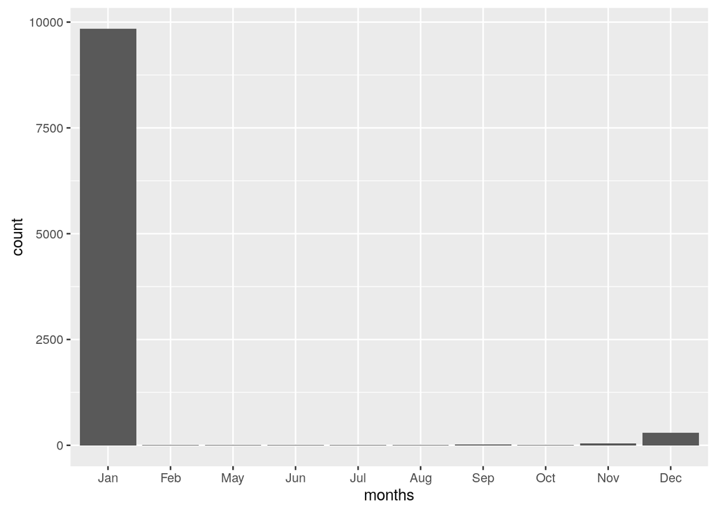

```r
ggplot(policeData,aes(policeData$month))+geom_bar()+xlab("months")
```

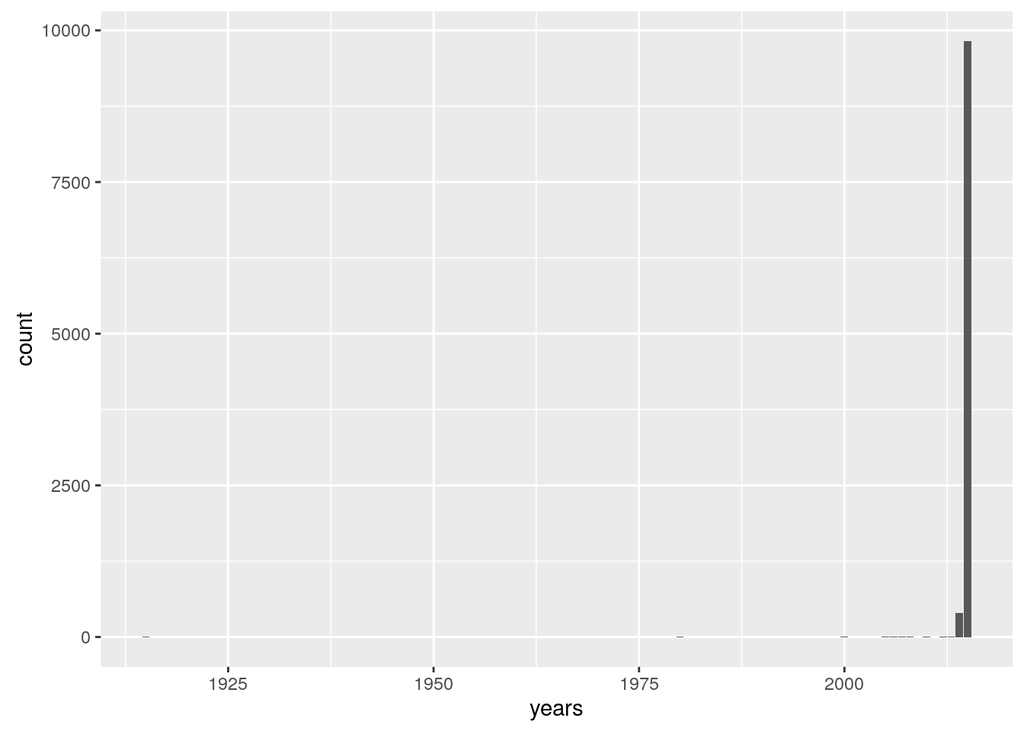

```r
ggplot(policeData,aes(policeData$year))+geom_bar()+xlab("years")
```

Now we will come to the information about the city and criminality How many beats does the city have:

```r
nrow(table(policeData$Beat))
```

```
## [1] 116
```

What kind of criminals are given?

```r
table(policeData$Offense_Type)
```

```
##
## Aggravated Assault         Auto Theft           Burglary
##                641               1131               1886
##             Murder               Rape            Robbery
##                 23                 62                838
##              Theft
##               5670
```

Coming now to the stastical informations: We are interested in

- How many offenses are occuring per hour
- How many offenses are occuring per weekday
- How many offenses are occuring per day
- which are the beats with the most offenses
- which are the beats with the least offenses